# Interaction networks, food webs, and complexity in ecology

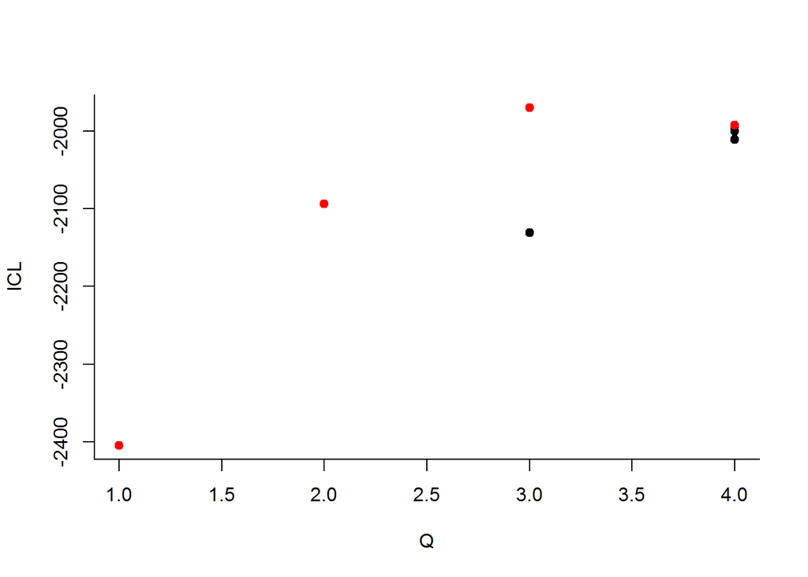

```
##         -> For 5 groups
##
```

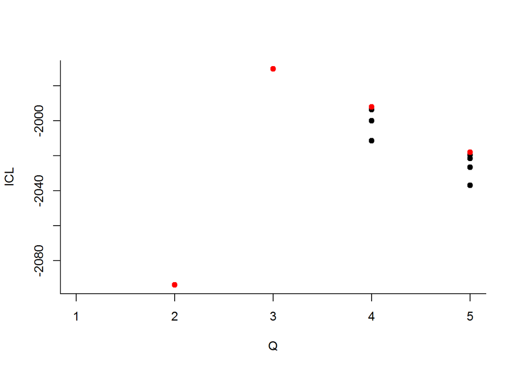

```
##     -> With descending number of groups
##         -> For 4 groups
##
```

```
##         -> For 3 groups
##
```

```
##         -> For 2 groups
##
```

```
## -> Pass 2
##     -> With ascending number of groups
##         -> For 2 groups
##         -> For 3 groups
##         -> For 4 groups
##         -> For 5 groups
##
```

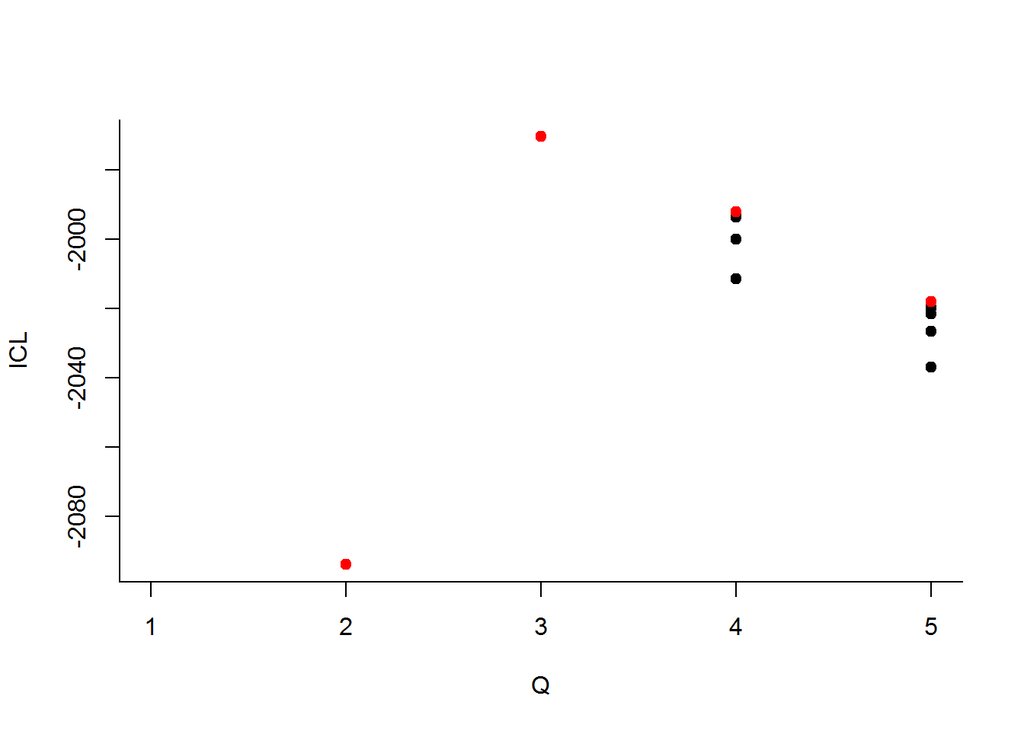

```
##     -> With descending number of groups
##         -> For 4 groups
##         -> For 3 groups
##         -> For 2 groups
```

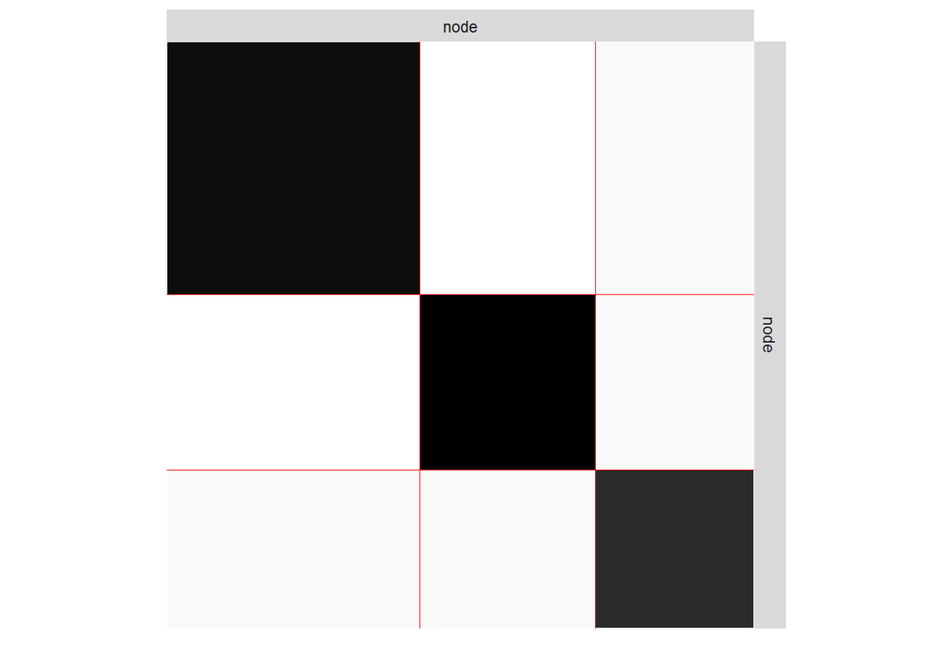

```r
plot(net.SBM, 'expected')
```

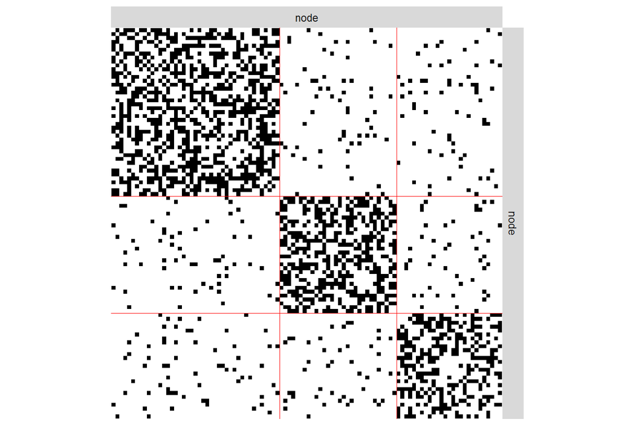

```r
plot(net.SBM, 'data')
```

### Modularity and blocks

It is possible to compare the partitionings of nodes obtained through modularity search and SBMs, for instance comparing the result of Louvain algorithm with a simple SBM on the network given by mat.

The alluvial plot helps visualize the correspondence between these groups.

```r
m.SBM <- estimateSimpleSBM(mat)
```

```
## -> Estimation for 1 groups
##
```

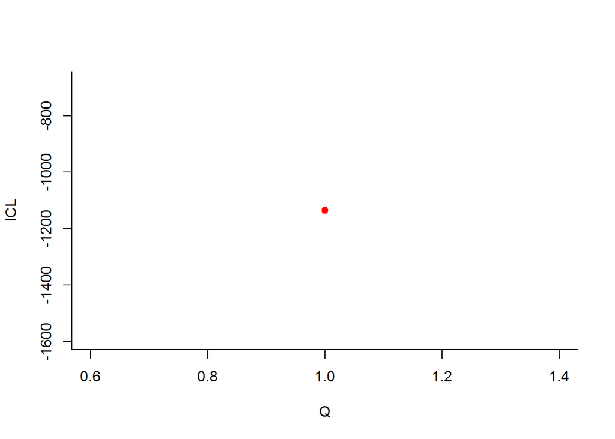

```
## -> Computation of eigen decomposition used for initalizations
##
## -> Pass 1
##     -> With ascending number of groups
##         -> For 2 groups
##
```

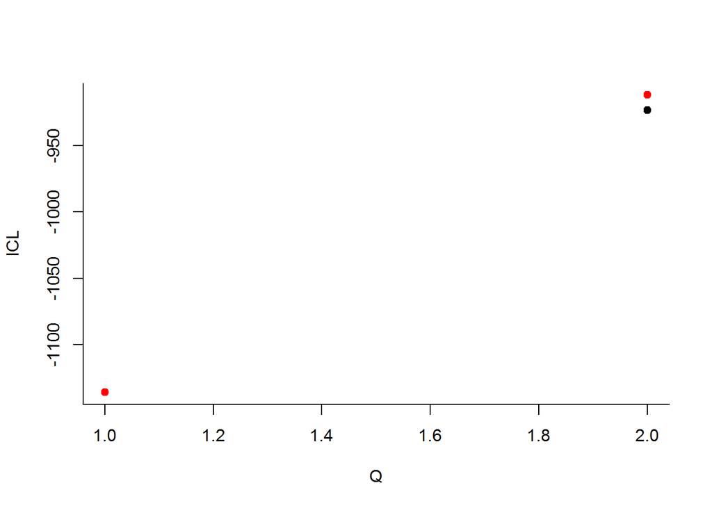

```
##         -> For 3 groups
##
```

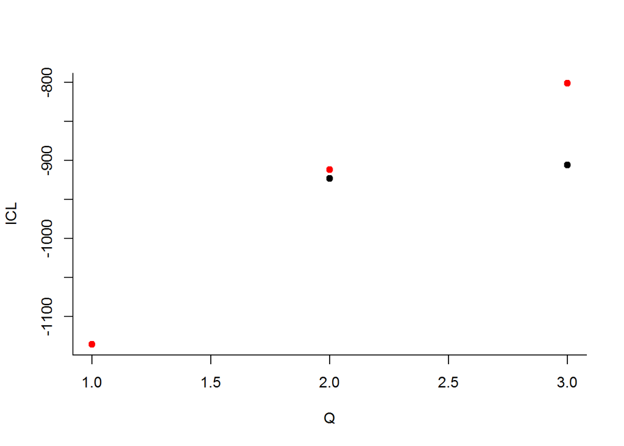

```
##         -> For 4 groups
##
```

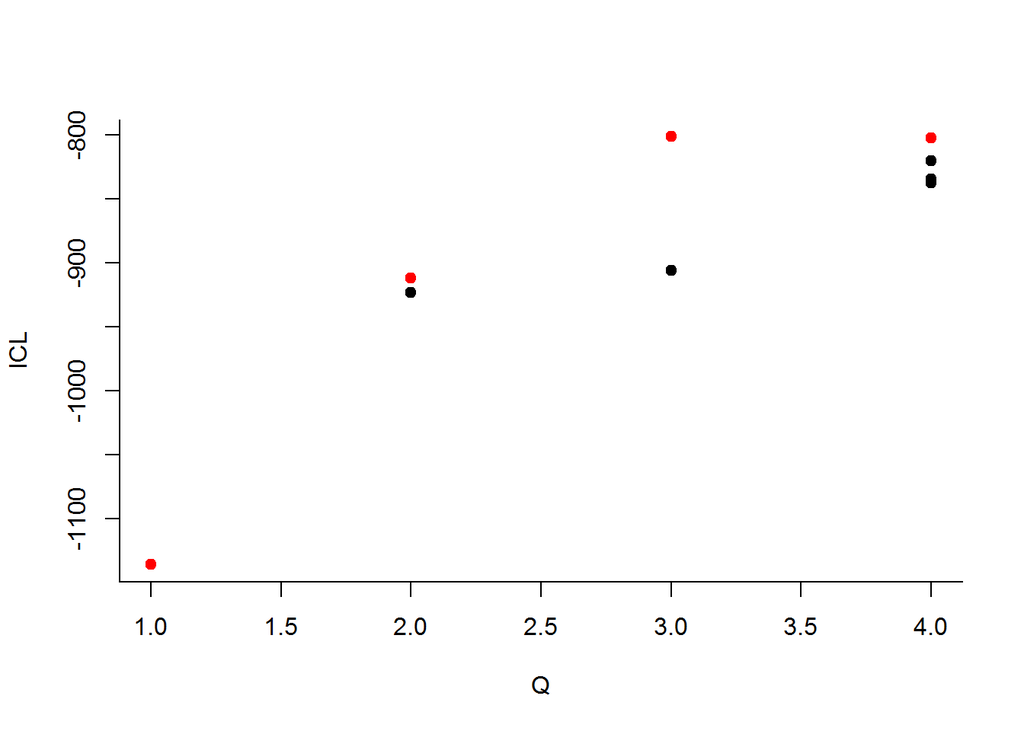

```
##         -> For 5 groups
##
```

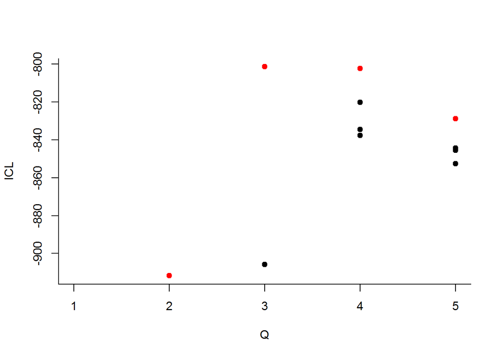

```
##     -> With descending number of groups
##         -> For 4 groups
##
```

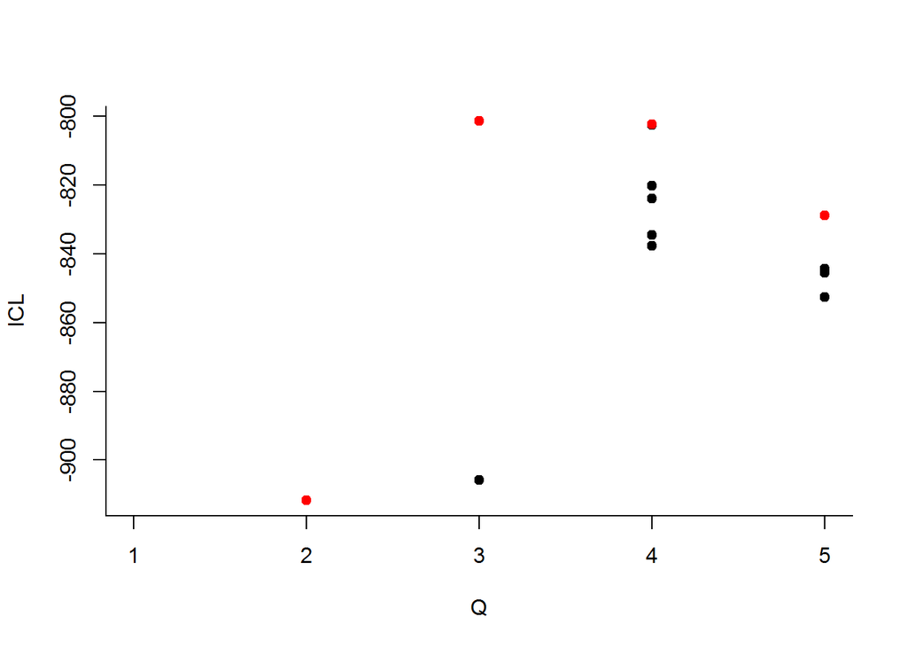

```
##         -> For 3 groups
##
```

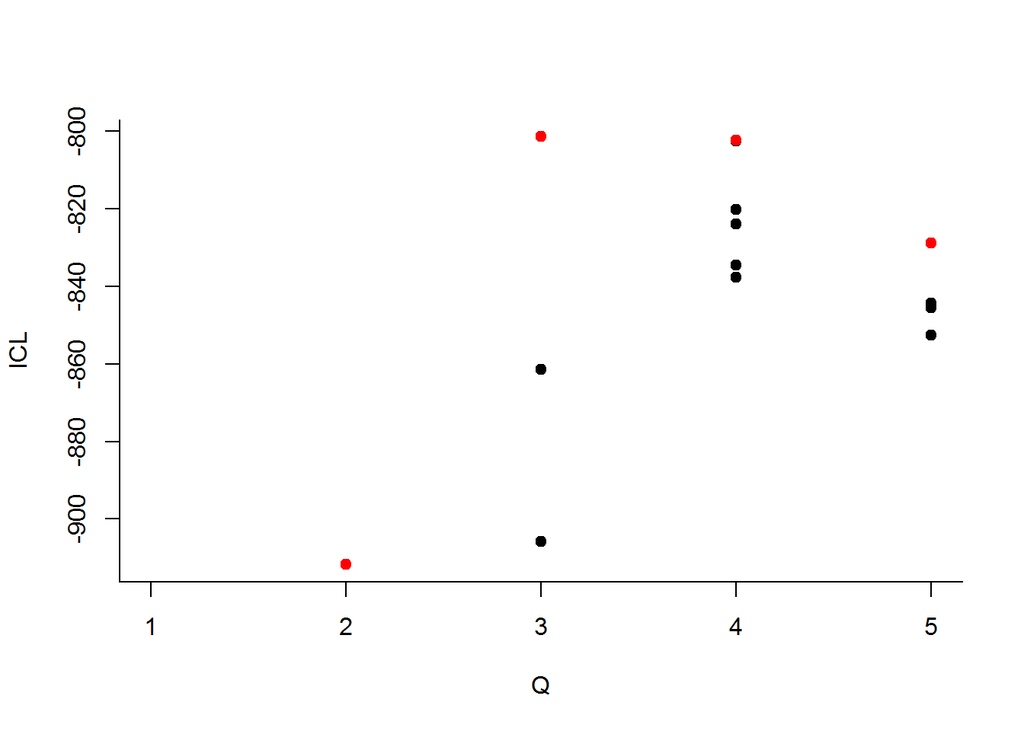

```
##         -> For 2 groups
##
```

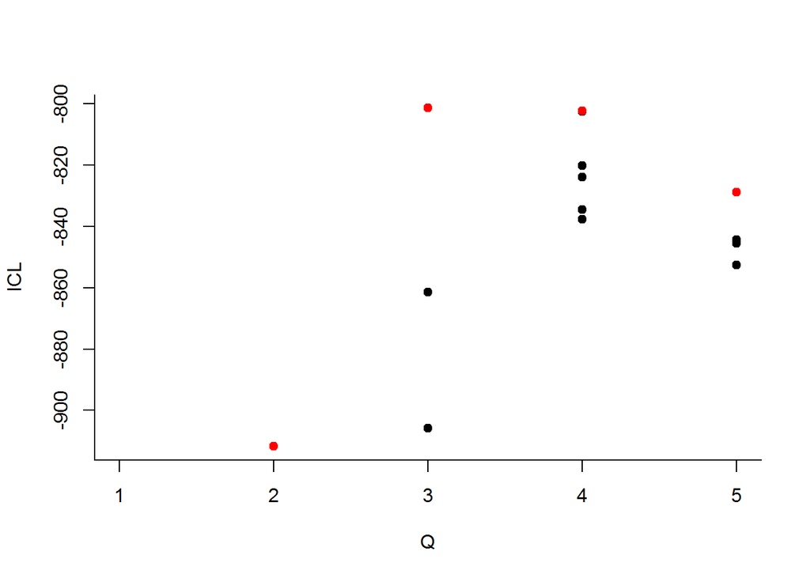

```
## -> Pass 2
##     -> With ascending number of groups
##         -> For 2 groups
##         -> For 3 groups
##         -> For 4 groups
##         -> For 5 groups
##     -> With descending number of groups
##         -> For 4 groups
##         -> For 3 groups
##         -> For 2 groups
```

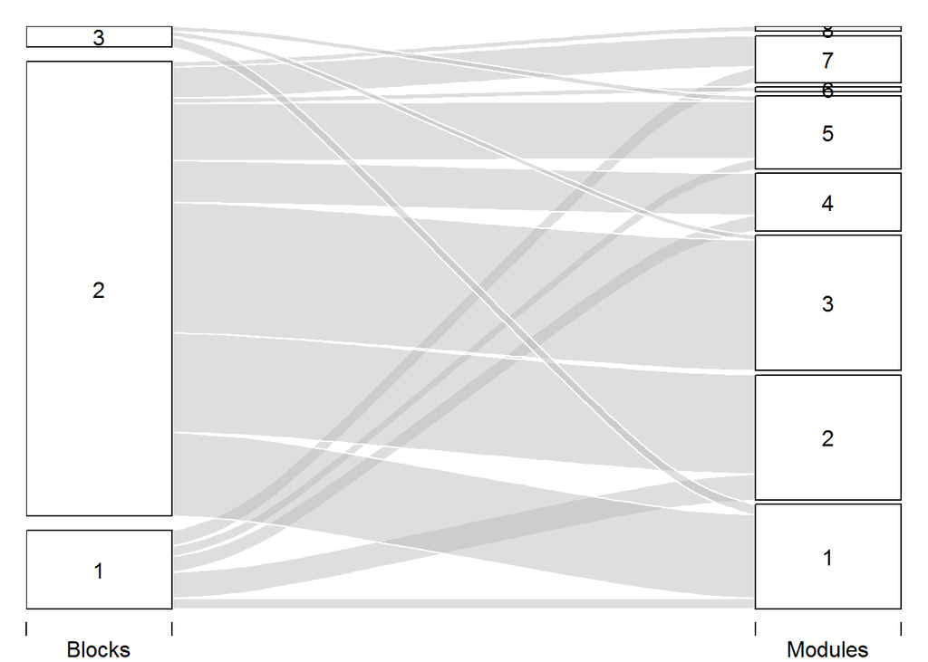

```r
modul<-cluster_louvain(graph_from_adjacency_matrix(mat,mode="undirected"))
make_alluvial_2(m.SBM$memberships,modul$membership,"Blocks","Modules")
```

It is also possible to look at whether these groupings have anything to do with trophic level (sensu MacKay et al.).

```r
count_components(net.mat)
```

```
## [1] 3
```

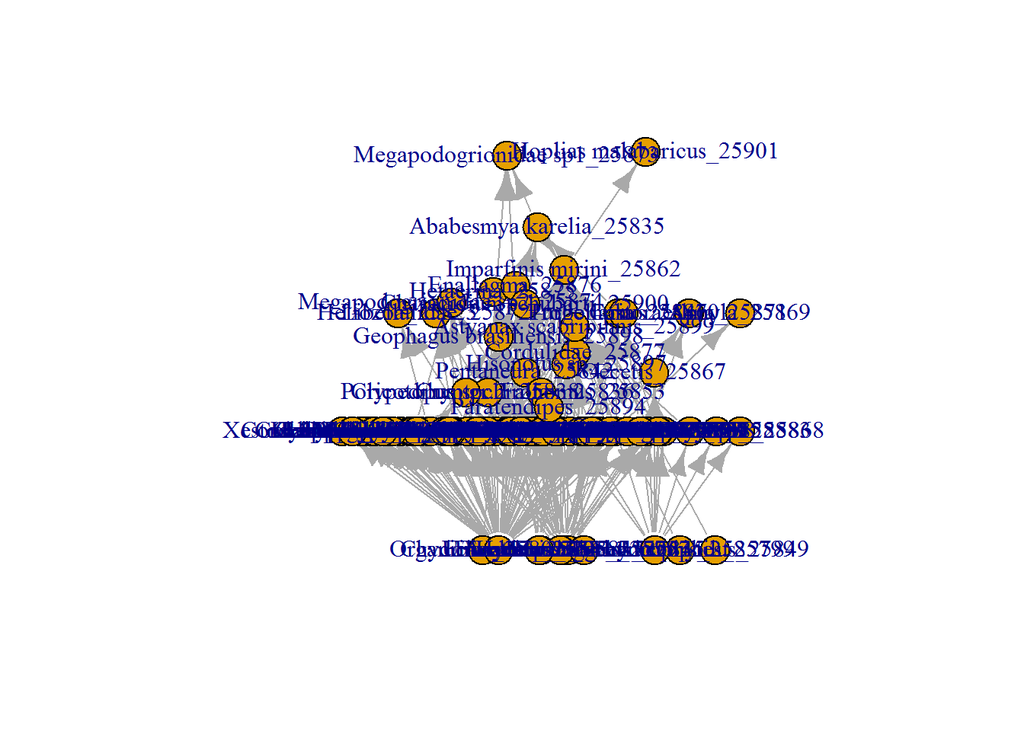

```r
net.comp<-components(net.mat)
tl.1<-trophic_levels(largest_component(net.mat))
plot(largest_component(net.mat),layout = layout_as_food_web)
```

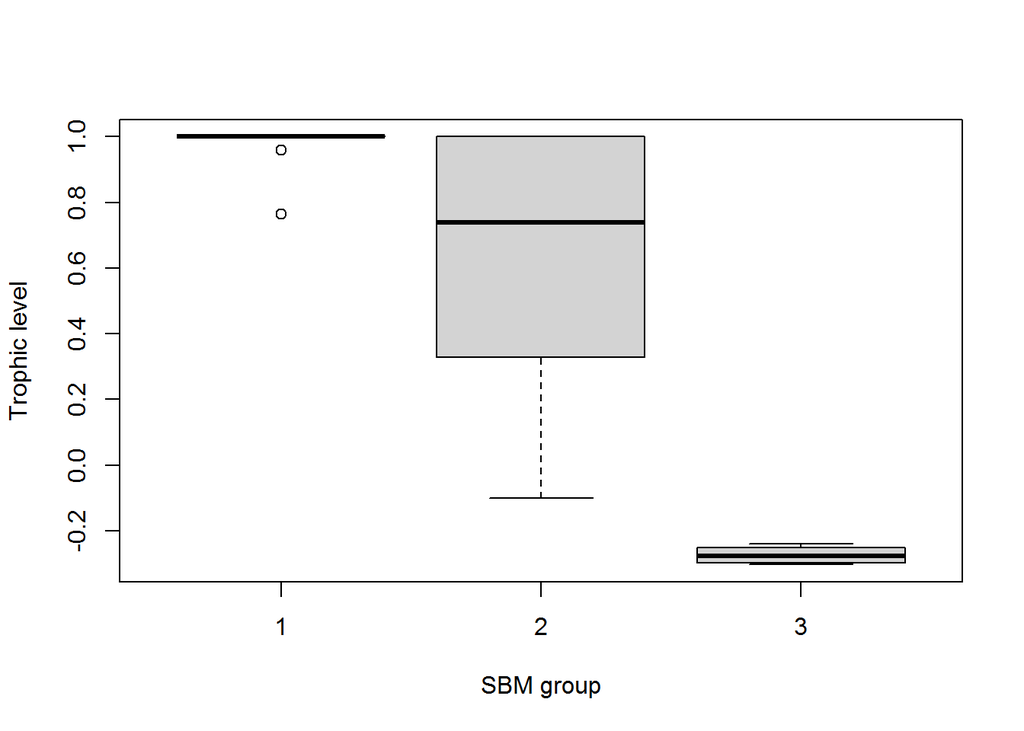

```r
plot(tl.1~as.factor(m.SBM$indMemberships[which(net.comp$membership==1),]%*%(1:3)),xlab="SBM group",ylab="Trophic level")
```

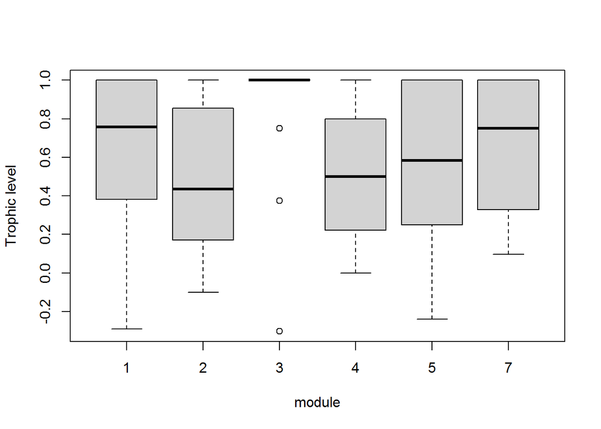

```r
plot(tl.1~as.factor(modul$membership[which(net.comp$membership==1)]),xlab="module",ylab="Trophic level")
```

As we can see, SBM-derived groups seem to be better at capturing trophic levels.

### Spectral clustering

One drawback of SBM is that they can be slow to converge, especially when the dataset is big. A convenient replacement algorithm when the number of groups to look for is known (or can be easily guessed) is spectral clustering. The idea of spectral clustering is to make use of the Laplacian matrix $L$ of the graph, given by:
$$L = D - A$$
where $D$ is the diagonal matrix of nodes’ degrees and $A$ is the adjacency matrix.

The Laplacian matrix has interesting properties, the best of all being that the number of zeros among its eigenvalues yield the number of components of the graph (one 0 means there is a single connected component, two zeros means the network is split in two disconnected components, etc.). The eigenvectors associated the zero eigenvalues can inform on the membership of nodes to the different components.

The heuristics of the spectral clustering is to use the eigenvectors associated with the set of small non-zero eigenvalues of $L$ to deduce the ``almost components’’ of the graph. To do so, one chooses a number of no-zero eigenvalues to keep and then the algorithm uses the associated eigenvector to find the groups through a K-means algorithm on the space obtained with these eigenvectors.

Here is an example of spectral clustering on the previous block-model graph.

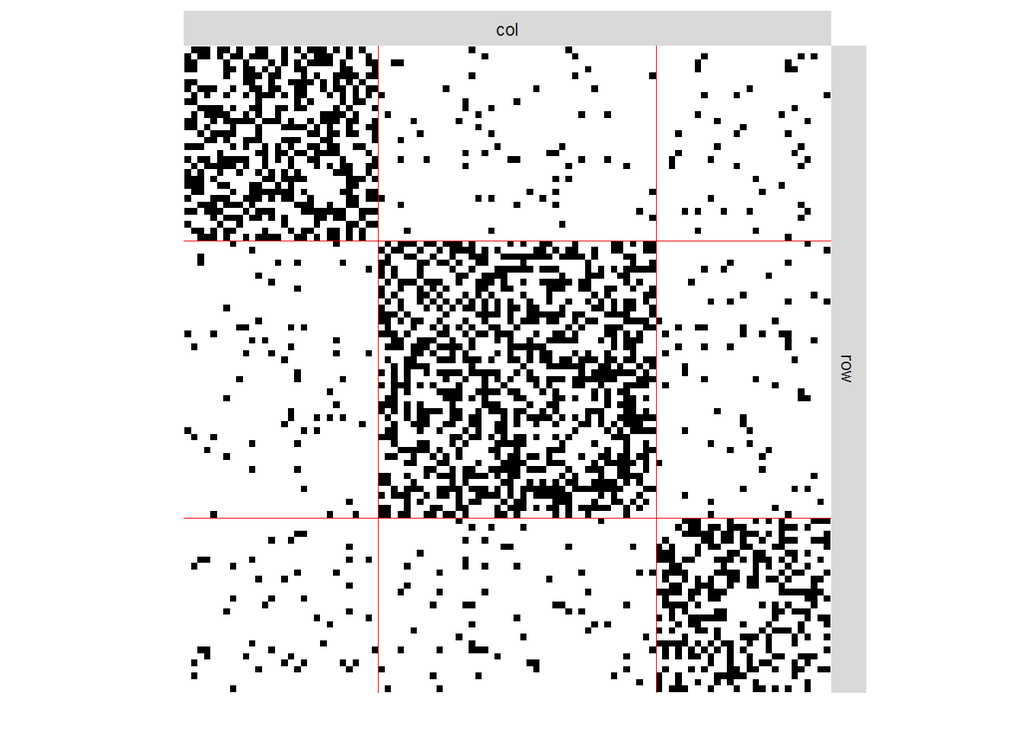

```r
SC<-spectral_clustering(graph_from_adjacency_matrix(sbmnet$networkData),3)
plotMyMatrix(sbmnet$networkData,clustering=list("row"=SC,"col"=SC))
```

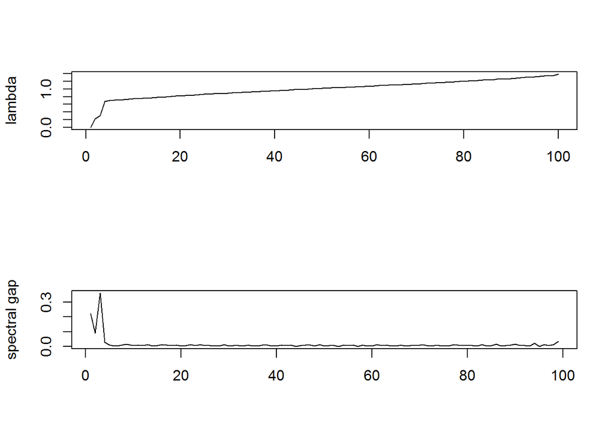

```
## $spectral_gaps
##  [1] 0.2223138696 0.0897456052 0.3624795777 0.0277945638 0.0091905797 0.0041921142 0.0064992973 0.0109255507 0.0113864509 0.0048118560
## [11] 0.0083440817 0.0056267457 0.0133965120 0.0021396969 0.0072149321 0.0112418416 0.0098163477 0.0053781316 0.0094076452 0.0034793014
## [21] 0.0062335568 0.0121545793 0.0070256658 0.0129043667 0.0071086801 0.0049614691 0.0022401982 0.0034567263 0.0125801221 0.0015993780
## [31] 0.0077226378 0.0048161537 0.0035079683 0.0105159887 0.0046036055 0.0043813651 0.0095206381 0.0097358254 0.0035507877 0.0029024229
## [41] 0.0084466126 0.0073300558 0.0082581384 0.0004282791 0.0071887086 0.0077448533 0.0089526321 0.0037138732 0.0111355848 0.0016262364
## [51] 0.0073763615 0.0064555522 0.0001200305 0.0086896398 0.0054347542 0.0082178142 0.0014615531 0.0096290065 0.0042976767 0.0031241465
## [61] 0.0109162226 0.0056458762 0.0102538550 0.0022349470 0.0026485747 0.0096220019 0.0025084584 0.0051632624 0.0048811885 0.0084763053
## [71] 0.0089098074 0.0041571858 0.0075123802 0.0072680733 0.0028565187 0.0038629779 0.0119072385 0.0088545457 0.0074359105 0.0059549129
## [81] 0.0067261089 0.0038962703 0.0120140648 0.0022472912 0.0061230230 0.0145706048 0.0038702086 0.0057972104 0.0082452611 0.0151058134
## [91] 0.0061377199 0.0074648706 0.0018962343 0.0205936455 0.0010496305 0.0130606744 0.0069507570 0.0138780405 0.0351524755
##
## $optim_n
## [1] 3
```

```r
laplacian_spectral_gap(graph_from_adjacency_matrix(sbmnet$networkData))
```

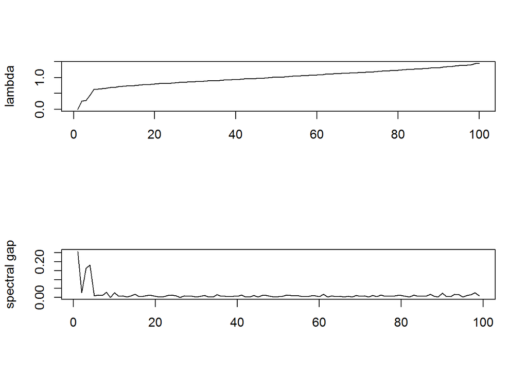

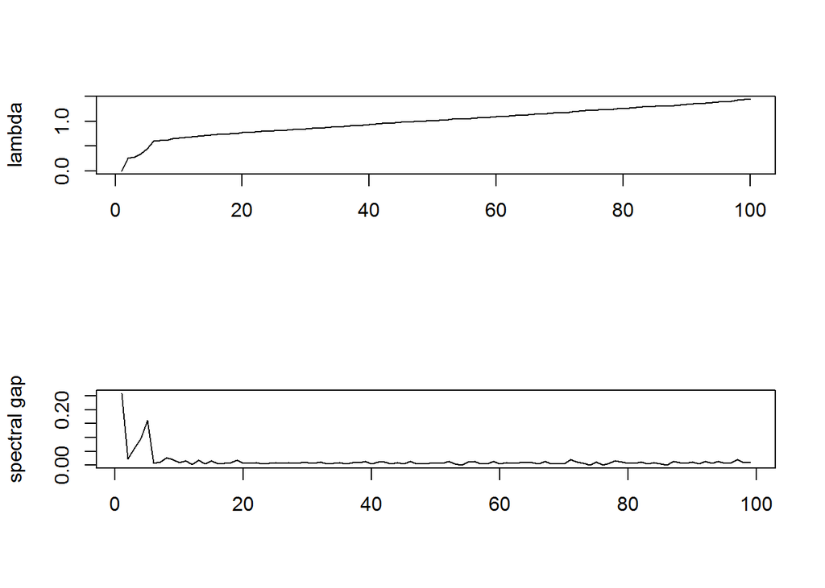

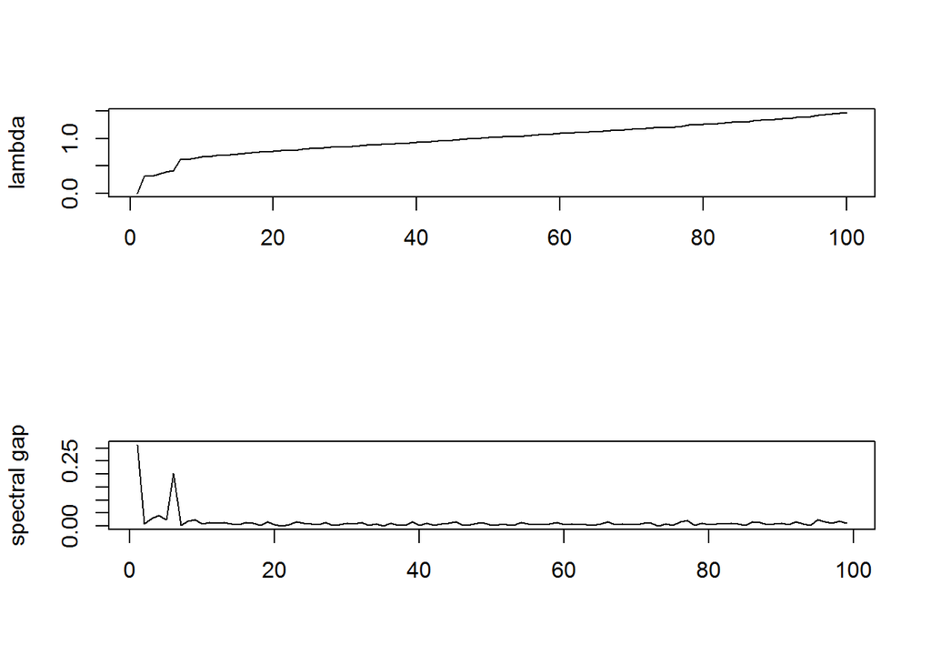

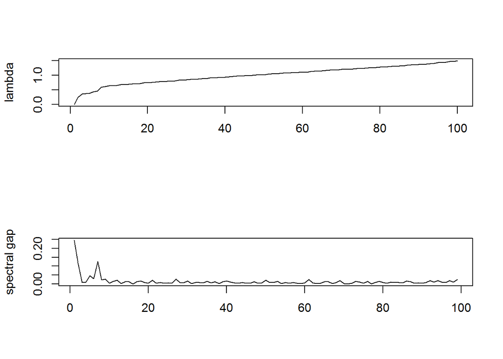

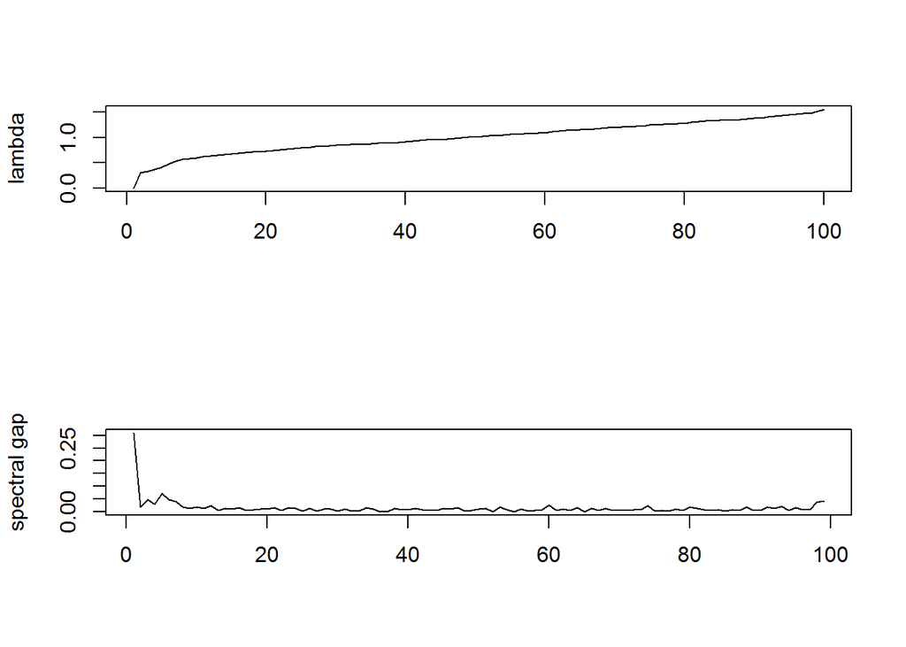

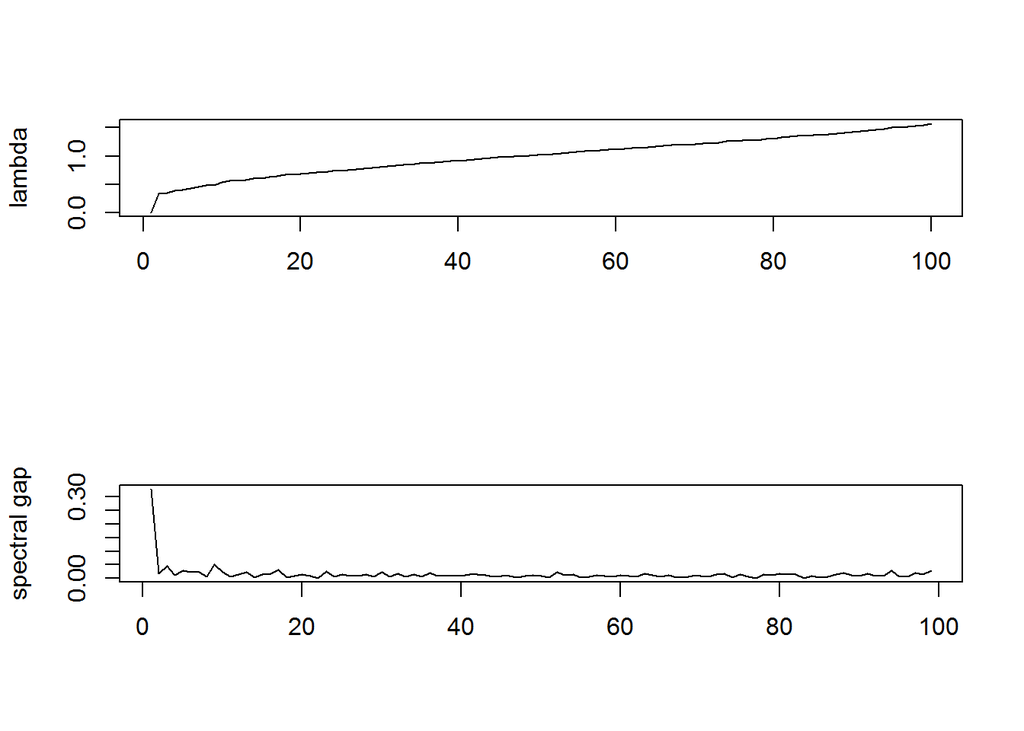

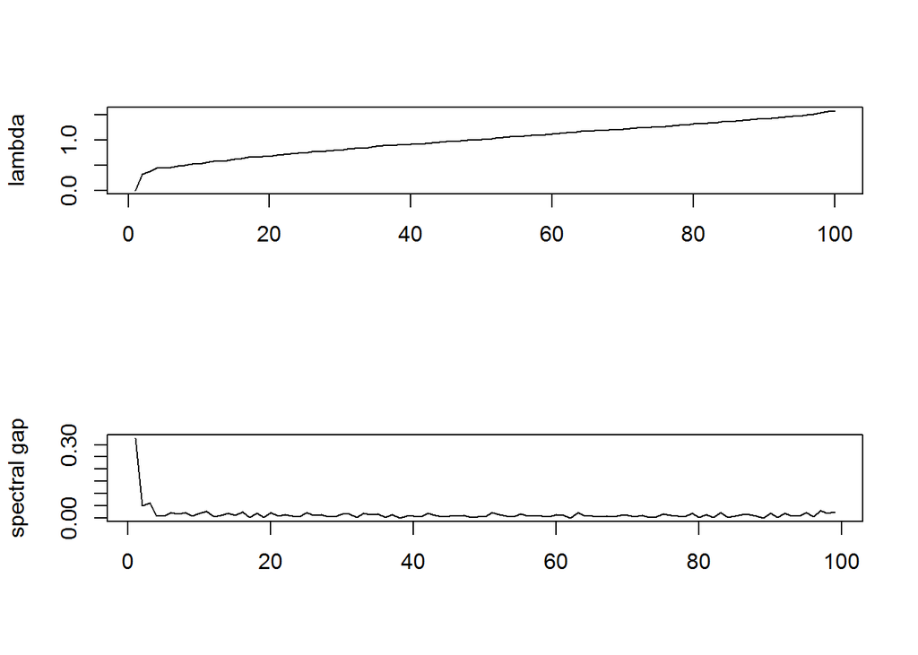

```r
optims<-sapply(4:10,function(n) laplacian_spectral_gap(graph_from_adjacency_matrix(sampleSimpleSBM(100, rep(1/n, n), list(mean = diag(.4, n) + 0.05), model = 'bernoulli')$networkData))$optim_n)
```

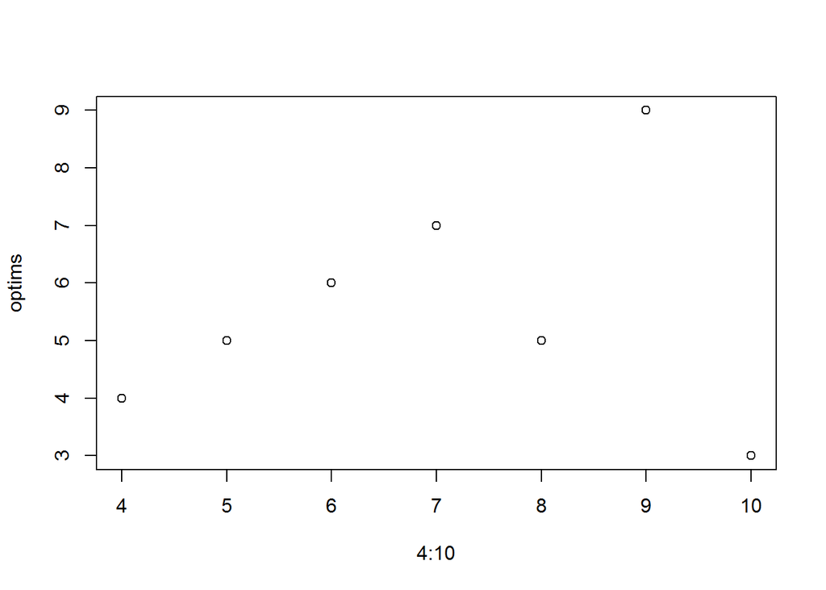

```r
par(mfrow=c(1,1))
plot(4:10,optims)
```

### Nestedness

The idea of nestedness is to measure the tendency for specialists to only interact with a subsample of the interactors of generalists. In other words, a network would be said “non-nested” only when specialists would interact more likely with specialists than with generalists.

Several indices have been developed over the years. Navigating their complexity is the purpose of the synthesis written by Podani and Schmera (2012).

I will not delve too long on the topic of nestedness because recent research seem to indicate that the concept is not really fruitful for a variety of reasons: - it seems to be very strongly linked to connectance - the diversity of nestedness indices tend to obfuscate its meaning (results reported show more about the index than about the concept) - these different indices can yield very different results when applied to the same dataset - in the classic case of power law distributions of degrees, the nestedness scores tend to be completely detrmined by the exponent of the power law - finally, when putting the common datasets in the right matrix ensemble (i.e. using correct null models to sample similar matrices), reported nestedness values seem to be completely expected.

### Last words

- ecological interaction networks can be used to study community or ecosystem properties
- random network models can help gauge generalities and specificities of networks
- all network patterns do not have a mechanistic model-based explanation yet, but some do (like the link between feasibility, stability, or robustness and connectance)
- interaction network data of different types lend themselves to different analyses (e.g. modularity for binary networks, value adjacency matrix with signed interactions for May-like analyses)

## Literature

Astegiano, J., Guimarães Jr, P. R., Cheptou, P.-O., Vidal, M. M., Mandai, C. Y., Ashworth, L. & Massol, F. (2015) Persistence of plants and pollinators in the face of habitat loss: Insights from trait-based metacommunity models. Advances in Ecological Research - vol. 53 (eds G. Woodward & D. A. Bohan), pp. 201-257. Academic Press.

Bizeul, P. & Najim, J. (2021) Positive solutions for large random linear systems. Proceedings of the American Mathematical Society, 149, 2333-2348.

Clauset, A., Shalizi, C. R. & Newman, M. E. J. (2009) Power-law distributions in empirical data. SIAM Review, 51, 661-703.

Dunne, J. A., Williams, R. J. & Martinez, N. D. (2002) Food-web structure and network theory: The role of connectance and size. Proceedings of the National Academy of Sciences, 99, 12917-12922.

Dunne, J. A., Williams, R. J. & Martinez, N. D. (2002) Network structure and biodiversity loss in food webs: robustness increases with connectance. Ecology Letters, 5, 558-567.

James, A., Pitchford, J. W. & Plank, M. J. (2012) Disentangling nestedness from models of ecological complexity. Nature, 487, 227-230.

Leger, J.-B., Daudin, J.-J. & Vacher, C. (2015) Clustering methods differ in their ability to detect patterns in ecological networks. Methods in Ecology and Evolution, 6, 474-481.

Lewinsohn, T. M., Prado, P. I., Jordano, P., Bascompte, J. & Olesen, J. M. (2006) Structure in plant-animal interaction assemblages. Oikos, 113, 174-184.

May, R. M. (1972) Will a large complex system be stable? Nature, 238, 413-414.

Newman, M. E. J. (2006) Modularity and community structure in networks. Proceedings of the National Academy of Sciences, 103, 8577-8582.

Pocock, M. J. O., Evans, D. M. & Memmott, J. (2012) The robustness and restoration of a network of ecological networks. Science, 335, 973-977.

Payrató-Borràs, C., Hernández, L. & Moreno, Y. (2019) Breaking the Spell of Nestedness: The Entropic Origin of Nestedness in Mutualistic Systems. Physical Review X, 9, 031024.

Podani, J. & Schmera, D. (2012) A comparative evaluation of pairwise nestedness measures. Ecography, 35, 889-900.

Stone, L. (2016) The Google matrix controls the stability of structured ecological and biological networks. Nature Communications, 7, 12857.

Strona, G., Nappo, D., Boccacci, F., Fattorini, S. & San-Miguel-Ayanz, J. (2014) A fast and unbiased procedure to randomize ecological binary matrices with fixed row and column totals. Nature Communications, 5.

Stumpf, M. P. H. & Porter, M. A. (2012) Critical truths about power laws. Science, 335, 665-666.

Thomas, M., Verzelen, N., Barbillon, P., Coomes, O. T., Caillon, S., McKey, D., Elias, M., Garine, E., Raimond, C., Dounias, E., Jarvis, D., Wencélius, J., Leclerc, C., Labeyrie, V., Cuong, P. H., Hue, N. T. N., Sthapit, B., Rana, R. B., Barnaud, A., Violon, C., Arias Reyes, L. M., Latournerie Moreno, L., De Santis, P. & Massol, F. (2015) A network-based method to detect patterns of local crop biodiversity: validation at the species and infra-species levels. Advances in Ecological Research, 53, 259-320.

Williams, R. J. & Martinez, N. D. (2000) Simple rules yield complex food webs. Nature, 404, 180-183.

Yang, Z., Algesheimer, R. & Tessone, C. J. (2016) A Comparative Analysis of Community Detection Algorithms on Artificial Networks. Scientific Reports, 6, 30750.

Yodzis, P. (1998) Local trophodynamics and the interaction of marine mammals and fisheries in the Benguela ecosystem. Journal of Animal Ecology, 67, 635-658.